# MyProject#1

Abdoul Fall

5/22/2021

# *Project 1: How does three of the most sports video games played affect the giants of video game console manufacturers ?*

## Mission Statement

- **organization and credibility of the data**

The Data for the stock prices of Sony, Microsoft and Nintendo were found on Yahoo finance where historical data for those three companies were retrieved since the year 2007. Yahoo finance is a credible and reliable source of data for stock prices and is ranked 15th among the largest news and media websites. The data are well organized and the historical prices can be found by entering a time period or a frequency.

- **Sort and filter the data**

This Part of the analysis will consist of getting the stock prices from Sony, Microsoft and Nintendo and then merge them together and look for any incongruencies in the data.

```r
library(quantmod)  #access historical stock prices
library(dplyr)
library(tidyverse)
library(gtrendsR)  #returns the popularity of google search terms over time
library(maps)      #creates maps of the United States.
```

```r
getSymbols(c("SONY","MSFT","NTDOY"))
```

```
## [1] "SONY"  "MSFT"  "NTDOY"
```

Merging the stock data into one data frame

```r
stocks <- data.frame("Sony" = SONY$SONY.Close, "Microsoft" = MSFT$MSFT.Close, "Nintendo"= NTDOY$NTDOY.Close, "Date" = as.Date(row.names(as.data.frame(SONY))))
```

Gathering the columns into key-value pairs to create a long format table and Reshaping the data frame so one column contains the type of stock

```r
 stock_v2 <- stocks %>%
  gather(key = "stock", value = "value", -Date)
```

### Stock Prices of Sony, Microsoft and Nintendo over the last 14 years

Plotting the stock prices of Sony, Microsoft and Nintendo

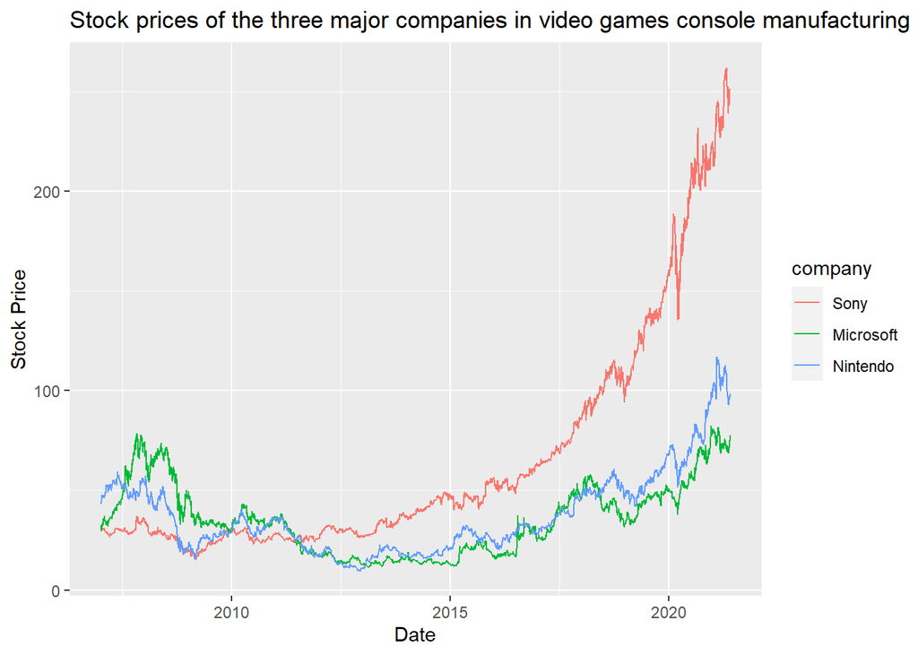

```r
stock_v2 %>%
  ggplot() + geom_line(aes(x = Date, y= value, color = stock)) +
  scale_color_discrete(name = "company", labels = c("Sony", "Microsoft", "Nintendo")) +
  labs(title = "Stock prices of the three major companies in video games console manufacturing", y = "Stock Price")
```

### popular sports video games trends on Google

This analysis consisted of retrieving data from google regarding how many times the three most popular sports video games were trending on Google and display those information (popularity of google search terms, trends or number of hits over time) which will be returned online by Google trends.

Creating a data frame consisting of the number of hits for NBA 2k, the most popular basketball video game, Madden NFL, the most popular Football video game and MLB The Show, the most popular baseball video game.

```r
trends <- gtrends(keyword=c("NBA 2k","Madden NFL", "MLB The Show"))
trends_over_time <- trends$interest_over_time
trends_over_time <- trends_over_time %>%
  mutate(hits = as.numeric(hits))
trends_over_time <- trends_over_time %>%
  replace_na(list(hits = 0))
```

Plotting the google trends for those three popular sports video games

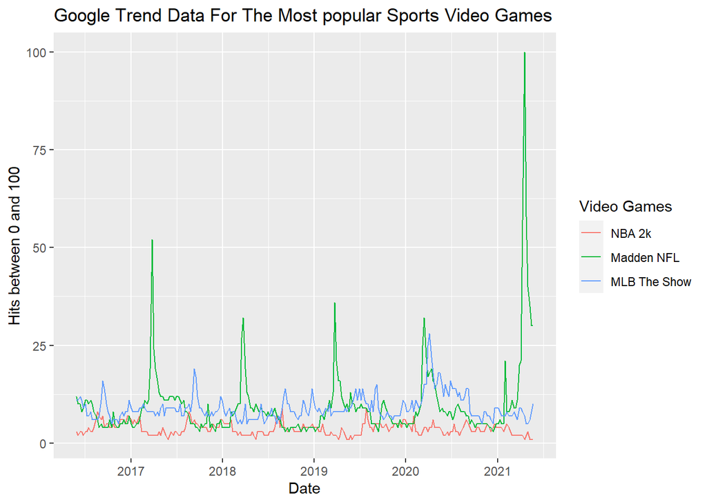

```r
trends_over_time %>% ggplot() + geom_line(aes(date, hits, color = keyword)) +
  scale_color_discrete(name = "Video Games", labels = c("NBA 2k","Madden NFL", "MLB The Show")) +
  labs(title = "Google Trend Data For The Most popular Sports Video Games", y = "Hits between 0 and 100", x = "Date")
```

Next, we are going to look at the the trend data and the interests for those video games by region and identify which video games have the most hits and the lowest hits by regions or states.

```r
state_trends <-  gtrends(keyword=c("NBA 2k","Madden NFL", "MLB The Show"), geo = "US")
states <- state_trends$interest_by_region
states <- states %>%
  mutate(location = tolower(location))
```

Getting the map data

```r
states_map <- map_data("state")
```

Plotting the map data

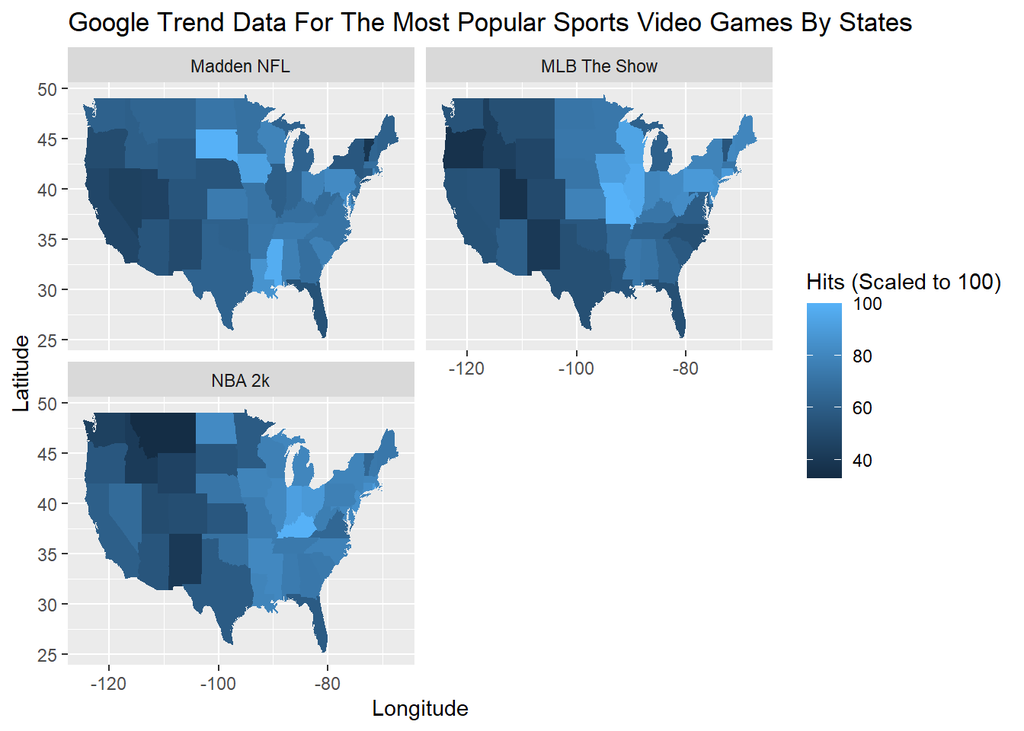

```r
states %>% ggplot(aes(map_id = location)) +
  geom_map(aes(fill = hits), map = states_map) +
  expand_limits(x = states_map$long, y = states_map$lat) +
  facet_wrap(~ keyword, nrow = 2) +
  labs(title = "Google Trend Data For The Most Popular Sports Video Games By States", x = "Longitude", y = "Latitude") +
  scale_fill_continuous(name = "Hits (Scaled to 100)")
```